# Total Auto Sales 2020(faked)

### Jie Guo

#### 2/11/2021

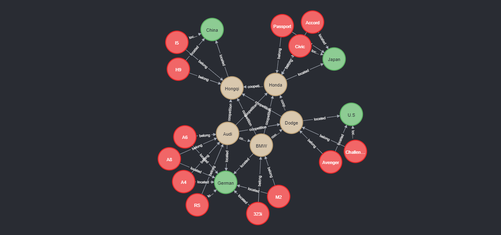

## Objective:

As the Data Analyst Team of **Karate Of Barack Epic (A.K.A KOBE) Auto**, which is the best dealer at west coastline, we have recived the report of Total Auto Sales 2020(faked) from our statistic department. Now we would like to combine our new technique to visalize this dataset and answer 5 business questions related to the potential benefits of K.O.B.E Vehicle.

- 1. Use Neo4j to create graphic database:
     - Nodes, Attributes and Relations

- 1. Five questions related to improvement if service and benefits:
     - Which manufacturer has the highest quantity of models in this database?
     - Which model is the best deal one for each horsepower?
     - The average sales for each model located in German;
     - Which manufacturer have the hightest sales?
     - Compare to the horsepower, which model has the best performence on MPG?

Finally, the conclusion and recommendation will be given.

```python
from neo4jrestclient.client import GraphDatabase
from py2neo import Graph, Node, Relationship
db =Graph("http://localhost:7474", username= "neo4j", password='523698741')
db.delete_all()
```

## 1.Creating Nodes, Attributes and Relations

```python
car1 = Node("model",name='A4')
car2 = Node("model",name='A6')
car3 = Node("model",name='A8')
car4 = Node("model",name='RS')
car5 = Node("model",name='Challenger')
car6 = Node("model",name='Avenger')
car7 = Node("model",name='323i')
car8 = Node("model",name='M2')
car9 = Node("model",name='Accord')
car10 = Node("model",name='Civic')
car11 = Node("model",name='Passport')
car12 = Node("model",name='H9')
car13 = Node("model",name='I5')
db.create(car1)
db.create(car2)
db.create(car3)
db.create(car4)
db.create(car5)
db.create(car6)
db.create(car7)
db.create(car8)
db.create(car9)
db.create(car10)
db.create(car11)
db.create(car12)
db.create(car13)


Manufacturer1 = Node("Manufacturer", name = "Audi")
Manufacturer2 = Node("Manufacturer", name = "BMW")
Manufacturer3 = Node("Manufacturer", name = "Dodge")
Manufacturer4= Node("Manufacturer", name = "Honda")

Manufacturer5= Node("Manufacturer", name = "Hongqi")


Country1 = Node("Country", country = "China", city = 'Beijing')
Country2 = Node("Country", country = "U.S", city = 'CA')
Country3 = Node("Country", country = "German", city = 'Berlin')
Country4 = Node("Country", country = "Japan", city = 'Tokyo')
db.create(Manufacturer1)
db.create(Manufacturer2)
db.create(Manufacturer3)
db.create(Manufacturer4)

db.create(Manufacturer5)

db.create(Country1)
db.create(Country2)
db.create(Country3)
db.create(Country4)
```

```python
car1_Manufacturer1 = Relationship(car1,'belong',Manufacturer1)
db.create(car1_Manufacturer1)
car2_Manufacturer1 = Relationship(car2,'belong',Manufacturer1)
db.create(car2_Manufacturer1)
car3_Manufacturer1 = Relationship(car3,'belong',Manufacturer1)
db.create(car3_Manufacturer1)
car4_Manufacturer1 = Relationship(car4,'belong',Manufacturer1)
db.create(car4_Manufacturer1)
car5_Manufacturer3 = Relationship(car5,'belong',Manufacturer3)
db.create(car5_Manufacturer3)
car6_Manufacturer3 = Relationship(car6,'belong',Manufacturer3)
db.create(car6_Manufacturer3)
car7_Manufacturer2 = Relationship(car7,'belong',Manufacturer2)
db.create(car7_Manufacturer2)
car8_Manufacturer2 = Relationship(car8,'belong',Manufacturer2)
db.create(car8_Manufacturer2)
car9_Manufacturer = Relationship(car9,'belong',Manufacturer4)
db.create(car9_Manufacturer)
car10_Manufacturer = Relationship(car10,'belong',Manufacturer4)
db.create(car10_Manufacturer)
car11_Manufacturer = Relationship(car11,'belong',Manufacturer4)
db.create(car11_Manufacturer)
car12_Manufacturer = Relationship(car12,'belong',Manufacturer5)
db.create(car12_Manufacturer)
car13_Manufacturer = Relationship(car13,'belong',Manufacturer5)
db.create(car13_Manufacturer)
```

```python
Manufacturer1_Country=Relationship(Manufacturer1,'located',Country3)
Manufacturer2_Country=Relationship(Manufacturer2,'located',Country3)
Manufacturer3_Country=Relationship(Manufacturer3,'located',Country2)
Manufacturer4_Country=Relationship(Manufacturer4,'located',Country4)
Manufacturer5_Country=Relationship(Manufacturer5,'located',Country1)

db.create(Manufacturer1_Country)
db.create(Manufacturer2_Country)
db.create(Manufacturer3_Country)
db.create(Manufacturer4_Country)
db.create(Manufacturer5_Country)
```

```python
car1_country=Relationship(car1,'located',Country3)
car2_country=Relationship(car2,'located',Country3)
car3_country=Relationship(car3,'located',Country3)
car4_country=Relationship(car4,'located',Country3)
car5_country=Relationship(car5,'located',Country2)
car6_country=Relationship(car6,'located',Country2)
car7_country=Relationship(car7,'located',Country3)

car8_country=Relationship(car8,'located',Country3)
car9_country=Relationship(car9,'located',Country4)
car10_country=Relationship(car10,'located',Country4)
car11_country=Relationship(car11,'located',Country4)
car12_country=Relationship(car12,'located',Country1)
car13_country=Relationship(car13,'located',Country1)

db.create(car1_country)
db.create(car2_country)
db.create(car3_country)
db.create(car4_country)
db.create(car5_country)
db.create(car6_country)
db.create(car7_country)
db.create(car8_country)
db.create(car9_country)
db.create(car10_country)
db.create(car11_country)
db.create(car12_country)
db.create(car13_country)
```

```python
Manufacturer1_Manufacturer2=Relationship(Manufacturer1,'coopetition',Manufacturer2)
Manufacturer1_Manufacturer3=Relationship(Manufacturer1,'coopetition',Manufacturer3)
Manufacturer1_Manufacturer4=Relationship(Manufacturer1,'coopetition',Manufacturer4)
Manufacturer1_Manufacturer5=Relationship(Manufacturer1,'coopetition',Manufacturer5)
Manufacturer2_Manufacturer3=Relationship(Manufacturer2,'coopetition',Manufacturer3)
Manufacturer2_Manufacturer4=Relationship(Manufacturer2,'coopetition',Manufacturer4)
Manufacturer2_Manufacturer5=Relationship(Manufacturer2,'coopetition',Manufacturer5)
Manufacturer3_Manufacturer4=Relationship(Manufacturer3,'coopetition',Manufacturer4)
Manufacturer3_Manufacturer5=Relationship(Manufacturer3,'coopetition',Manufacturer5)
Manufacturer4_Manufacturer5=Relationship(Manufacturer4,'coopetition',Manufacturer5)
db.create(Manufacturer1_Manufacturer2)
db.create(Manufacturer1_Manufacturer3)
db.create(Manufacturer1_Manufacturer4)
db.create(Manufacturer1_Manufacturer5)
db.create(Manufacturer2_Manufacturer3)
db.create(Manufacturer2_Manufacturer4)
db.create(Manufacturer2_Manufacturer5)
db.create(Manufacturer3_Manufacturer4)
db.create(Manufacturer3_Manufacturer5)
db.create(Manufacturer4_Manufacturer5)
```

```python
car1['HP'] = 300
car1['price'] = 17998
car1['MPG'] = 25
car1['sale'] = 21232
car1['BrandDescrpition'] = 'Make your life better!'

car2['HP'] = 310
car2['price'] = 16799
car2['MPG'] = 23
car2['sale'] = 13229

car3['HP'] = 270
car3['price'] = 17000
car3['MPG'] = 30
car3['sale'] = 10213
car3['BrandDescrpition'] = 'Try you will know'

car4['HP'] = 260
car4['price'] = 25000
car4['MPG'] = 29
car4['sale'] = 7312

car5['HP'] = 330
car5['price'] = 35000
car5['MPG'] = 26
car5['sale'] = 9895
car5['sale'] = 9899
car5['BrandDescrpition'] = 'Toyota the better life'
car5['rate'] = 4.5

car6['HP'] = 350
car6['price'] = 11000
car6['MPG'] = 18
car6['sale'] = 15919
car6['type'] = 'sedan'

car7['HP'] = 220
car7['price'] = 12000
car7['MPG'] = 33
car7['sale'] = 33919
car7['rate'] = 4.8

car8['HP'] = 500
car8['price'] = 13000
car8['MPG'] = 15
car8['sale'] = 12332

car9['HP'] = 230
car9['price'] = 14000
car9['MPG'] = 29
car9['sale'] = 53123
car9['BrandDescrpition'] = '200 years making cars perfect'

car10['HP'] = 325
car10['price'] = 17000
car10['MPG'] = 22
car10['sale'] = 62132

car11['HP'] = 525
car11['price'] = 47000
car11['MPG'] = 20
car11['sale'] = 13423
car11['type'] = 'sedan'
car11['cylinder'] = 8

car12['HP'] = 425
car12['price'] = 67000
car12['MPG'] = 19
car12['sale'] = 32142
car12['type'] = 'sedan'

car13['HP'] = 178
car13['price'] = 33333
car13['MPG'] = 35
car13['sale'] = 19823
car13['type'] = 'suv'

db.push(car1)
db.push(car2)
db.push(car3)
db.push(car4)
db.push(car5)
db.push(car6)
db.push(car7)
db.push(car8)
db.push(car9)
db.push(car10)
db.push(car11)
db.push(car12)
db.push(car13)
```

```python
Manufacturer1['Country'] = 'Germany'
Manufacturer1['CEO'] = 'AAAA'
Manufacturer1['Year'] = 1888

Manufacturer2['Country'] = 'Germany'
Manufacturer2['CEO'] = 'BBB'
Manufacturer2['Year'] = 1900

Manufacturer3['Country'] = 'U.S'
Manufacturer3['CEO'] = 'CCC'
Manufacturer3['Year'] = 1910

Manufacturer4['Country'] = 'Japan'
Manufacturer4['CEO'] = 'DDD'
Manufacturer4['Year'] = 1915

db.push(Manufacturer1)
db.push(Manufacturer2)
db.push(Manufacturer3)
db.push(Manufacturer4)
```

## 1.Which manufacturer has the highest quantity of models in this database?

```python
def most_model_manufacturer(tx):
    Audi = [i for i in tx.run('match (m:model)-[:belong]->(M:Manufacturer{name:"Audi"}) return count(m), M.name')]
    Honda = [i for i in tx.run('match (m:model)-[:belong]->(M:Manufacturer{name:"Honda"}) return count(m), M.name')]
    Hongqi = [i for i in tx.run('match (m:model)-[:belong]->(M:Manufacturer{name:"Hongqi"}) return count(m), M.name')]
    Dodge = [i for i in tx.run('match (m:model)-[:belong]->(M:Manufacturer{name:"Dodge"}) return count(m), M.name')]
    BMW = [i for i in tx.run('match (m:model)-[:belong]->(M:Manufacturer{name:"BMW"}) return count(m), M.name')]
    total = [Audi, Honda, Hongqi, Dodge, BMW]
    final = Audi
    for i in total:
        if i[0].get('count(m)') > final[0].get('count(m)'):
            final = i
        else:
            pass
    print(Audi)
    print(final[0].get('M.name'), 'is the manufacturer has the most of the models as',final[0].get('count(m)'),'models')
```

```python
most_model_manufacturer(db)
```

```
[Record({'count(m)': 4, 'M.name': 'Audi'})]
Audi is the manufacturer has the most of the models as 4 models
```

## 2.Which model is the best deal one for each horsepower?

```python
def hp_per_dollar(tx):
    print('Which model is the best deal one for each horsepower?')
    name = [i for i in tx.run('match (m:model) return m.name')]
    horsepower = [i for i in tx.run('match (m:model) return m.HP')]
    price = [i for i in tx.run('match (m:model) return m.price')]
    model = 0
    h_per_d = 10000
    for i in range(len(name)):
        h_per_d_new = price[i].get('m.price')/horsepower[i].get('m.HP')
        if h_per_d_new < h_per_d:
            h_per_d = h_per_d_new
            model = name[i].get('m.name')
        else:
            pass
    print('If you purchase', model, ", you got the best deal which is", h_per_d, "dollars per horsepower")
```

```python
hp_per_dollar(db)
```

```
Which model is the best deal one for each horsepower?
If you purchase M2 , you got the best deal which is 26.0 dollars per horsepower
```

## 3.The average sales for each Germany model.

```python
def count_german_models(tx):
    print('The average sales for each Germany model is: ')
    res_list = [res for res in tx.run('match (m:model)-[:located]->(:Country{country:"German"}) return m.sale')]
    total = 0
    for i in range(len(res_list)):
        total += res_list[i].get('m.sale')
    print(total/len(res_list))
```

```python
count_german_models(db)
```

```
The average sales for each Germany model is:
16372.833333333334
```

## 4.Which manufacturer have the hightest sales?

```python
def print_highest_Sales(tx):
    Audi = [i for i in tx.run('match (m:model)-[:belong]->(M:Manufacturer{name:"Audi"}) return sum(m.sale), M.name')]
    Honda = [i for i in tx.run('match (m:model)-[:belong]->(M:Manufacturer{name:"Honda"}) return sum(m.sale), M.name')]
    Hongqi = [i for i in tx.run('match (m:model)-[:belong]->(M:Manufacturer{name:"Hongqi"}) return sum(m.sale), M.name')]
    Dodge = [i for i in tx.run('match (m:model)-[:belong]->(M:Manufacturer{name:"Dodge"}) return sum(m.sale), M.name')]
    BMW = [i for i in tx.run('match (m:model)-[:belong]->(M:Manufacturer{name:"BMW"}) return sum(m.sale), M.name')]
    total = [Audi, Honda, Hongqi, Dodge, BMW]
    final = Audi
    for i in total:
        if i[0].get('sum(m.sale)') > final[0].get('sum(m.sale)'):
            final = i
        else:
            pass
    print(final[0].get('M.name'), 'is the manufacturer has the highest sales of all its models as',final[0].get('sum(m.sale)'),'sales.')
```

```python
print_highest_Sales(db)
```

```
Honda is the manufacturer has the highest sales of all its models as 128678 sales.
```

## 5.Compare to the horsepower, which model has the best performence on MPG?

```python
def mpg_per_hp(tx):
    print('Compare to the horsepower, which model has the best performence on MPG?')
    name = [i for i in tx.run('match (m:model) return m.name')]
    horsepower = [i for i in tx.run('match (m:model) return m.HP')]
    mpg = [i for i in tx.run('match (m:model) return m.MPG')]
    model = 0
    m_per_h = 0
    for i in range(len(name)):
        m_per_h_new = horsepower[i].get('m.HP')/mpg[i].get('m.MPG')
        if m_per_h_new > m_per_h:
            m_per_h = m_per_h_new
            model = name[i].get('m.name')
        else:
            pass
    print('If you purchase', model, ", you got the best deal which is", m_per_h, "horsepower for Miles Per Gallon")
```

```python
mpg_per_hp(db)
```

```
Compare to the horsepower, which model has the best performence on MPG?
If you purchase M2 , you got the best deal which is 33.333333333333336 horsepower for Miles Per Gallon
```